# appui trame pédagogique

Diane

10 octobre 2019

## Habillage technique du grimoire

C’est la solution `{learnr}` qui permet l’interactivité dans la console qui est envisagée. Pour le parcours A, on envisagera des options de type `{parsons}` (réordonner des bouts de code ou des bouts de réponse à la façon d’un puzzle), là où les parcours B seront amenés à taper du code dans la console, quitte à le faire sur des “textes à trous”

`{learnr}` permet également de poser des questions de type QCM

Les modules ci-après sont décrits par objectifs pédagogiques (à habiller narrativement) et par un déroulé suggéré avec différentes modalités pédagogiques parfois scindées selon les parcours.

## Module 0 : Introduction

Objectif pédagogique :

- comprendre ce qu’est R, à quoi ça sert
- être à l’aise avec la console et l’erreur
- comprendre ce que signifie “sensibilité à la casse”

Déroulé :

- Description des objectifs du modules
- Présenter R (open source, multi-plateforme) et ses possibilités (graphiques, calculatoires, web, SIG…)
- Présenter la programmation avec R comme un dialogue avec la console
- Décrire la boîte de dialogue qui s’offre à eux
- Faire afficher un jeu de données (déjà chargé), si possible celui qui servira dans le prochain module
- Constater qu’écrire `Dataset` en lieu et place de `dataset` renverra une erreur (et la dédramatiser)

Remarques : reprendre une bonne partie de la partie rédigée par Arnaud ?

## Module 1 - Visualiser

Objectifs pédagogiques :

- comprendre les notions de couches graphiques
- tracer un nuage de point
- tracer un diagramme en barre
- tracer un diagramme en barre empilé (parcours B ?)

Déroulé :

- Rappel des acquis précedents (afficher un jeu de données)
- Description des objectifs du module : tracer des graphiques
- Rappeler ou expliquer que les graphiques servent à matérialiser des “relations” entre des variables
- Avant de faire tracer le premier graphique, faire réfléchir à la relation “attendue” entre 2 variables sur un jeu de données donné
- Exemple indicatif (mais un nuage de point serait plus pertinent en première intention)

Question : “il naît en proportion plus de filles que de garçons en France”, VRAI ou FAUX ?

Voyons ce qu’il en est, on affiche seulement le graphique :

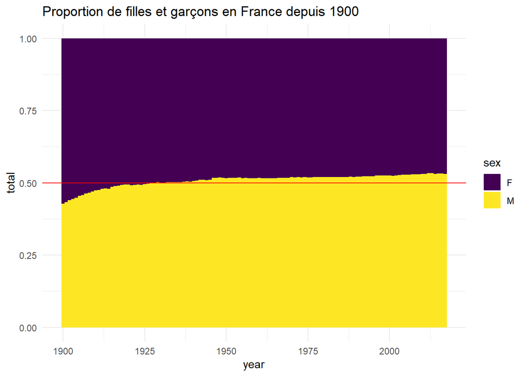

Question : Au vu des éléments graphiques fournis : est-ce qu’il naît plus de filles que de garçons ? (excellente question n’est-ce pas ;-) ? et surtout, comment l’expliquer ?)

Explication de la décomposition du graphique : des données (data), un axe des `x`/un axe des `y` (aes) et une “géométrie” (geom) qu’on superpose.

```r
ggplot(un_dataset_bien_formate)+
  aes(x = les_x, y = les_y) +
  geom_bar()
```

On propose ensuite un exercice où c’est aux participants de compléter ou de changer une valeur

Itérer pour chacun des types de graphiques : 1. S’interroger sur la relation attendue a priori (et donc réfléchir aux `x` et `y`, à la “géométrie”) 2. Tracer 3. conclure 4. Présenter la géométrie qui correspond 5. Essayer avec de nouvelles valeurs, un nouveau jeu de données

Parcours A == ggformula et Parcours B == ggplot2 ?

## Module 2 - Décrire et comprendre

Objectif pédagogique :

- comprendre la notion de fonction (définie syntaxiquement par `()`)
- appliquer une fonction de description sur un jeu de données
- comprendre la notion de paramètre
- passer des paramètres à une fonction de description d’un jeu de données (parcours B seulement ?)
- comprendre comment enchaîner des fonctions avec le `%>%`

Déroulé :

- Rappel des acquis précédents (afficher un jeu de données, tracer un graphique)
- Description des objectifs du modules
- Donner des clefs pour identifier les fonctions (syntaxe dans R avec `()`)
- Une fonction très utile pour décrire par exemple `summary(dataset)` à comparer avec `dataset`
- Qu’est-ce qu’une fonction en fait ? - schéma d’une fonction- : des inputs (ou pas) et des outputs
- Utilisons une autre fonction avec un output différent `skimr::skim(donnee)`
- Passons un paramètre `skimr::skim(donnees, unevariable)`, pointer l’existence de la `,`
- Introduction du `%>%`, notion de grammaire avec `verbe(sujet, complément)` devient `sujet %>% verbe(complément)`

Sensibiliser aussi au fait que

```r
sujet %>% verbe(complément)
```

est strictement équivalent à :

```r
sujet %>%
  verbe(complément)
```

On pourra reformuler l’idée avec `%>%` avec “ensuite”

```r
dataset %>%
  summary()
```

se lira :

> je prends un jeu de données et *ensuite*, je fais un résumé
- Tester l’application de la fonction `skim` sur un nouveau jeu de données
- Tester la bonne assimilation du pipe avec des “lectures”

Exemple, donner un bloc de code et en proposer quelques interprétations avec du code vu :

```r
dataset %>%
  ggplot()+
  aes(x = abscisses, y = ordonnees)+
  geom_bar()
```

Introduire l’enchaînement de pipes sur du pseudo code :

```r
farine %>%
  ajouter(sucre, oeufs, lait) %>%
  fouetter() %>%
  cuire() %>%
  manger("crêpes")
```

> Je prends de la farine, *ensuite*, j’ajoute du sucre, des oeufs, du lait, *ensuite*, je fouette, *ensuite*, je cuis, *ensuite* je mange…des crêpes

(tout habillage narratif avec Icarius est le bienvenu)

## Module 3 - Manipuler et transformer

Objectif pédagogique :

- savoir sélectionner une colonne
- découvrir les opérateurs `==`, `&` et `|`
- découvrir les opérateurs `!=`, `%in%`, `!` (parcours B)
- savoir filtrer un jeu de données
- savoir trier un jeu de données

Déroulé :

- Rappel des acquis précédents (afficher un jeu de données, tracer un graphique, décrire avec une fonction, enchaîner des opérations)
- Décrire les objectifs du module (sélectionner, filtrer et trier)
- Décrire ce que signifie sélectionner (réduire le jeu de données en *largeur*), illustrer avec un schéma
- Décrire la syntaxe dans `select()`, insister sur la `,`
- Experimenter la sélection de variables sur un exemple
- Tester en faisant s’enchaîner une selection de variable et un `skimr`

Leur faire réaliser que

```r
donnees %>%
  select(une_variable) %>%
  skimr::skim()
```

est identique à :

```r
donnees %>%
  skimr::skim(une_variable)
```

- Décrire ce que signifie trier (réduire le jeu de données en *hauteur*) - illustrer avec un schéma
- Introduire la notion de critère de tri, faire émerger le besoin d’outils pour ce faire
- Présenter ce qu’est un opérateur
- Présenter `==`, `&` et `|`
- Tester sur de menus exemple en dehors de `filter()`
- Montrer la syntaxe dans `filter()` et y inscrire un premier critère
- Tester les opérateurs dans `filter()`
- Idem pour les autres opérateurs
- Décrire ce que signifier trier (réordonner selon un critère, de façon croissante ou décroissante)
- Montrer la syntaxe de `arrange()` - y compris en combinant plusieurs critères (parcours B seulement ? )
- Tester la bonne application de la syntaxe sur un critère
- Finir avec un exercice qui combine `select()`, `filter()`, `arrange()` (+ plot pour les plus joueurs ? )

## Module 3bis - Manipuler et transformer (mutate, summarise, group_by avec les helpers) - OPTIONNEL

## Module 3ter - Manipuler et transformer (verbes scopés _if, _at, _all) - OPTIONNEL

## Module 4 - Nettoyer (transposer) - OPTIONNEL

## Module 4bis - Nettoyer (traiter les données manquantes) - OPTIONNEL

## Module 5 - Importer

Objectifs pédagogiques :

- comprendre la notion d’assignation (`<-`)
- comprendre la notion de package
- savoir décrypter un fichier en entrée (séparateur de colonne, séparateur décimaux)
- savoir importer un fichier csv (parcours B)
- savoir importer un fichier excel, SAS (parcours B)

Déroulé :

- Expliquer que les jeux de données ne seront pas toujours mis à disposition et que leur import nécessite des clefs de lecture
- Décrire la séparateur de colonne
- Décrire le séparateur décimal
- Expliquer comment les trouver dans un fichier csv
- Décrire la syntaxe (insister sur les guillemets)

```r
read.csv(chemin_de_fichier, sep = ";", dec = ",")
```

Remarque : j’ai un doute sur la faisabilité technique de leur faire réellement lancer cette ligne dans learnr…

- Présenter la notion de package, illustrer par un schéma
- Expliquer que `library(package)` rend disponible des fonctionnalités (de packages déjà *installés*)
- Expliquer au moyen d’un schéma quelles fonctions appartiennent à quels packages et les faire charger les packages `{ggplot2}`, `{dplyr}` (les packages vus jusqu’ici)
- Tester la notion en les faisant charger `{readr}`
- Leur faire importer un `.csv` avec `read_csv()` (et constater que ça passe sans paramètres)
- Expliquer les principes de l’assignation (faire vivre dans la mémoire, donner un *certificat de naissance* aux jeu de données) via le symbole d’assignation
- “Lire” le code comme une phrase

```r
mon_jeu_de_donnees <- read_csv("chemin_d'ordinateur/registre.csv")
```

> `mon_jeu_de_donnees` vaut le fichier `registre.csv` que l’on peut trouver à l’adresse `chemin_d'ordinateur` (Attention à bien jouer sur le `code` et le “français” visuellement parlant)
- Proposer de “lire” plusieurs “phrases”

```r
ma_valeur <- 6

mon_tableau <- un_tableau %>%
  filter(une_variable > ma_valeur)
```

- Tester la bonne compréhension des phrases

> `ma_valeur` vaut `6`

> `mon_tableau` vaut `un_tableau` filtré sur `une_variable` strictement supérieure à `ma_valeur` (qui vaut `6`)

Idem pour les imports de fichiers Excel pour le parcours B ?

## Module 5bis - Importer (Fusionner des jeux de données) - OPTIONNEL

## Module 6 - Uppercut ! Rejouer

Objectifs pédagogiques :

- comprendre la notion de reproductibilité
- mobiliser toutes les connaissances acquises dans un ordre typique de l’analyse de données (importer, manipuler et transformer, tracer des graphiques, résumer et comprendre)
- savoir écrire des commentaires `#`

Déroulé

- Expliquer le lien entre la programmation et la reproductibilité
- Leur faire lire plusieurs blocs de code à la suite qui ressembleraient à un embryon d’analyse : importer, décrire, visualiser, transformer.
- Les faire changer le jeu de données en input de la chaîne de traitement
- Satisfaire leur souhait de vouloir commenter les résultats en introduisant la notion de commentaire avec le symbole `#`
- Les inviter à saisir quelques commentaires

## Module 7 - Communiquer

Objectifs pédagogiques :

- découvrir la programmation lettrée
- comprendre ce qu’est un RMarkdown
- savoir compiler un Rmardown pré-rempli (à remplir/compléter pour le parcours B ?)

Déroulé :

- Faire intuiter que l’uppercut du module précédent donne envie d’ajouter des commentaires aux graphiques et tableau : c’est précisément ce que nous allons faire avec un outil spécial
- Présenter RStudio, à quoi ça sert
- Créer un nouveau projet RStudio
- Ouvrir un template RMarkdown (modèle ad hoc, pré-rempli, avec charte graphique ?)
- Expliquer comment RMarkdown peut répondre à ce besoin de commenter en “tissant” des liens étroits entre le code et la rédaction -illustrer par un schéma et/ou capture d’écran-
- Décrire les zones d’un fichier `.Rmd`
- Les faire compiler (tricoter) un premier RMarkdown (en docx ?)
- Indiquer où se situe le fichier de sortie.

Remarque :

- ce module ne peut se faire que dans RStudio
- J’ai exploré la piste du package `{editR}` qui permet de modifier un RMarkdown en temps réel, mais le package nécessiterait une refonte totale pour une exploitation en production.